# Week 4 R Markdown & pnorm

Jian Zheng

2024-02-15

# Load packages

```r
library(dplyr)
```

```r
library(ggplot2)
library(openintro)
```

# Norm

Normal distribution

## pnorm

The `pnorm()` function finds the *proportion* that is below a **certain value** on the Normal distribution. This, as with the other Normal distribution functions, have a default value of

- 0 for the mean and
- 1 for the standard deviation.

```r
pnorm(1)
```

```
## [1] 0.8413447
```

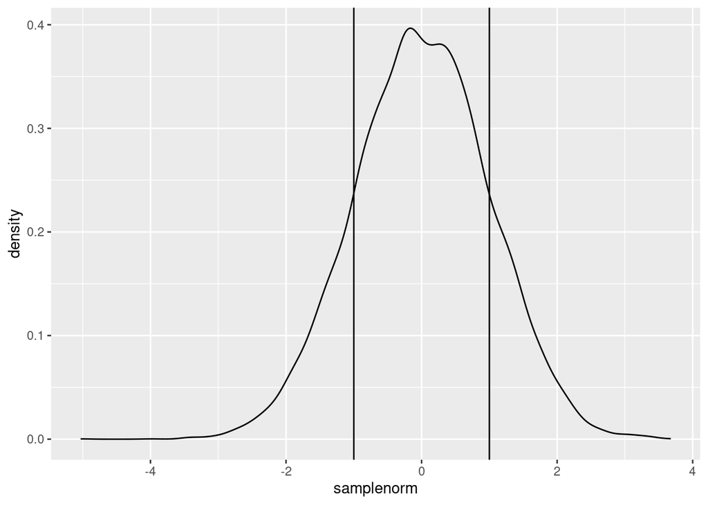

```r
samplenorm <- rnorm(10000)
samplenorm_df <- data.frame(samplenorm)
samplenorm_df %>% ggplot(aes(samplenorm))+geom_density()+geom_vline(xintercept = 1)+geom_vline(xintercept = -1)
```

```r
pnorm(1) # below 1, on the left side of 1
```

```
## [1] 0.8413447
```

```r
1 - pnorm(1) # above 1, on the right side of 1
```

```
## [1] 0.1586553
```

```r
pnorm(1) - pnorm(-1) # between -1 and 1
```

```
## [1] 0.6826895
```

## qnorm

We can use `qnorm()` to go the opposite way – if we want to know what the cutoff is for a certain percentile.

```r
samplenorm_1 <- rnorm(10000, 10, 2)
```

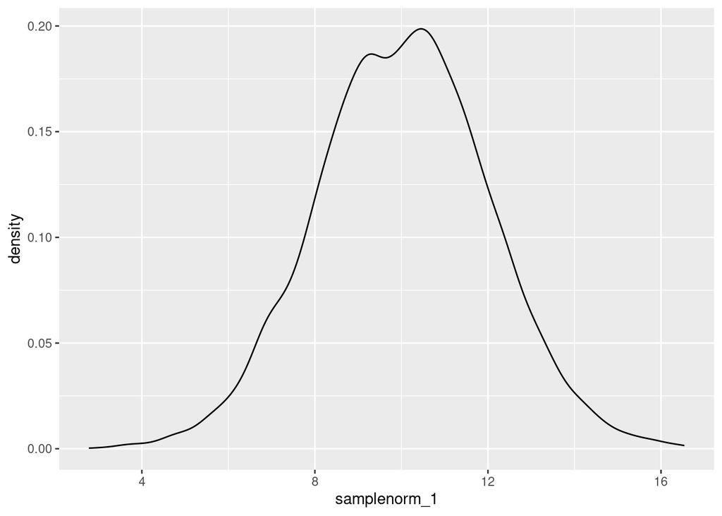

```r
samplenorm_1_df <- data.frame(samplenorm_1)
samplenorm_1_df %>% ggplot(aes(samplenorm_1))+geom_density()
```

above 95% (or the top 5%)

```r
qnorm(.95, 10, 2)
```

```
## [1] 13.28971
```

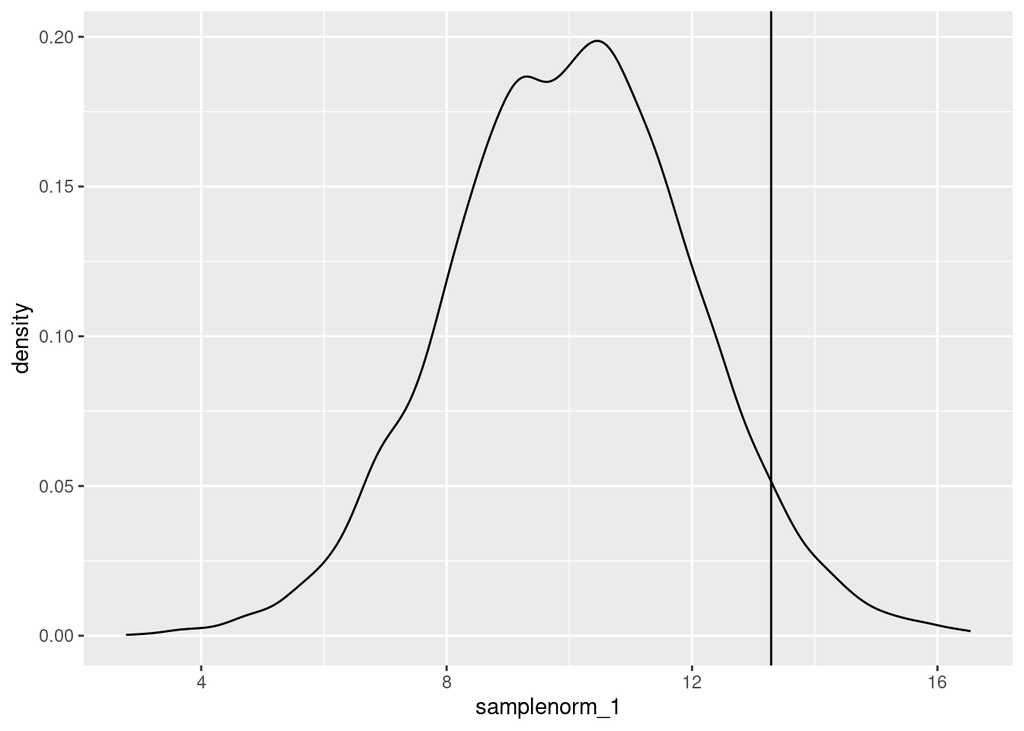

```r
samplenorm_1_df %>% ggplot(aes(samplenorm_1))+geom_density()+geom_vline(xintercept =  13.289)
```

# Calculate the percentage between a range

`filer` and `nrow`

```r
data("email")
```

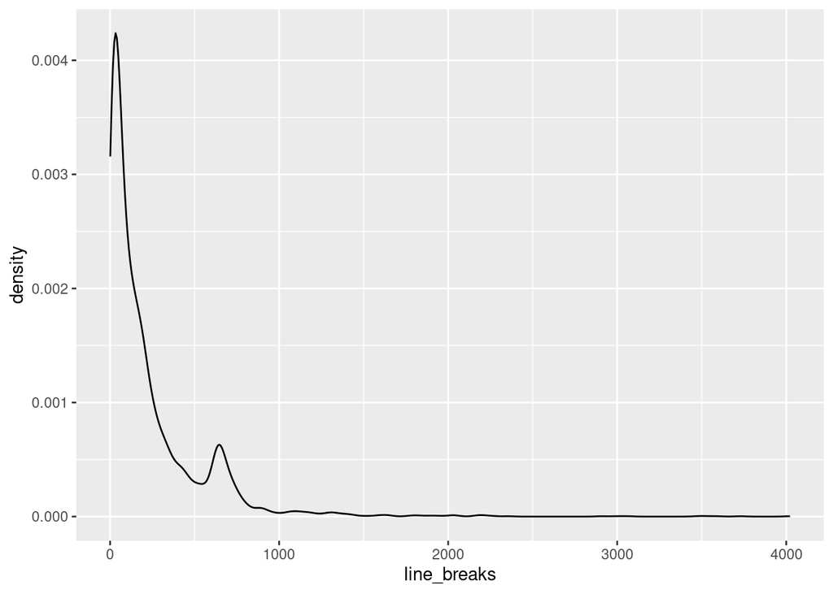

```r
email %>% ggplot(aes(x = line_breaks)) + geom_density()
```

Between 500 and 1000 lines

```r
email %>% filter((line_breaks < 1000) & (line_breaks > 500)) %>% nrow()
```

```
## [1] 493
```

```r
nrow(email)
```

```
## [1] 3921
```

```r
493/3921
```

```
## [1] 0.1257332
```

# R Markdown

1. Embedding R Code in Markdown Documents: R code can be embedded in chunks ({r} … ) to execute code and display results within the document. Run a chunk or a line
2. Markdown Syntax: Heading: Prefix the line with # for a heading. More #s indicate subheadings (e.g., ##, ###). Bold: Wrap text with ** or __ (e.g., **bold**). Italic: Wrap text with * or _ (e.g., *italic*). List: Ordered and Unordered: Unordered: Use - or * followed by a space. Ordered: Use numbers followed by a period and space (e.g., 1. , 2. ).
3. YAML header Configures document parameters like title, author, and output format. Knitting Documents Html, pdf, word